# Tarea 1 - Tablas de Mortalidad - CÁLCULO ACTUARIAL

## Parte 3: Diferencias y verificación

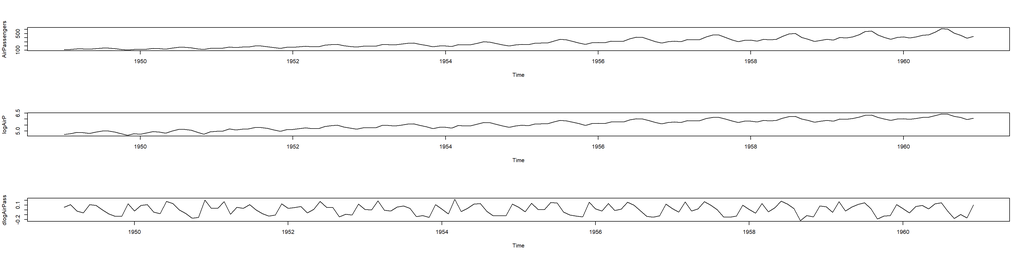

```r
# Diferencia regular
dlogAirPass = diff(logAirP)

par(mfrow=c(3,1))
plot(AirPassengers); plot(logAirP); plot(dlogAirPass)
```

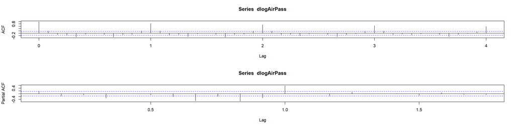

```r
par(mfrow=c(2,1))
acf(dlogAirPass, lag.max = 48)
pacf(dlogAirPass)
```

```r
aTSA::adf.test(dlogAirPass, nlag = 15)
```

```
Augmented Dickey-Fuller Test
alternative: stationary

Type 1: no drift no trend
      lag     ADF p.value
 [1,]   0  -9.606  0.0100
 [2,]   1  -8.816  0.0100
 [3,]   2  -7.634  0.0100
 [4,]   3  -8.745  0.0100
 [5,]   4  -6.791  0.0100
 [6,]   5  -6.245  0.0100
 [7,]   6  -6.571  0.0100
 [8,]   7  -9.498  0.0100
 [9,]   8  -8.028  0.0100
[10,]   9 -10.214  0.0100
```

[output cut: 41 more lines]

[figure not shown]

```r
# Diferencia estacional
d_dlogAirPass = diff(dlogAirPass, 12)

par(mfrow=c(4,1))
plot(AirPassengers); plot(logAirP); plot(dlogAirPass); plot(d_dlogAirPass)
```

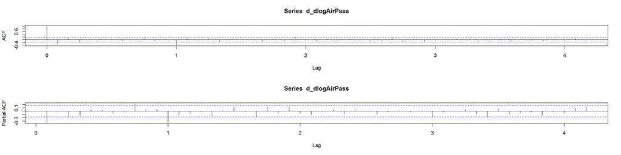

```r
par(mfrow=c(2,1))
acf(d_dlogAirPass, lag.max = 50)
pacf(d_dlogAirPass, lag.max = 50)
```

```r
aTSA::adf.test(d_dlogAirPass, nlag = 15)
```

```
Augmented Dickey-Fuller Test
alternative: stationary

Type 1: no drift no trend
      lag    ADF p.value
 [1,]   0 -16.25    0.01
 [2,]   1  -9.34    0.01
 [3,]   2  -8.65    0.01
 [4,]   3  -7.70    0.01
 [5,]   4  -6.11    0.01
 [6,]   5  -5.23    0.01
 [7,]   6  -5.03    0.01
 [8,]   7  -4.72    0.01
 [9,]   8  -3.38    0.01
[10,]   9  -2.96    0.01
```

[output cut: 41 more lines]

**Interpretación:**  
Tras $d=1, D=1$, la serie estacionariza: ACF y PACF ya no muestran picos periódicos ni tendencia.

## Parte 4: Ajuste de posibles modelos SARIMA

Se prueban tres modelos con transformación $\lambda=0$:

```r
# 1) ARIMA(1,1,1)x(0,1,1)[12]
Mod1 = forecast::Arima(
  AirPassengers,
  order    = c(1,1,1),
  seasonal = c(0,1,1),
  lambda   = 0,
  method   = "ML"
)

# 2) ARIMA(0,1,1)x(0,1,1)[12]
Mod2 = forecast::Arima(
  AirPassengers,
  order    = c(0,1,1),
  seasonal = c(0,1,1),
  lambda   = 0,
  method   = "ML"
)

# 3) ARIMA(1,1,0)x(0,1,1)[12]
Mod3 = forecast::Arima(
  AirPassengers,
  order    = c(1,1,0),
  seasonal = c(0,1,1),
  lambda   = 0,
  method   = "ML"
)

Mod2; Mod3
```

```
Series: AirPassengers
ARIMA(0,1,1)(0,1,1)[12]
Box Cox transformation: lambda= 0

Coefficients:
          ma1     sma1
      -0.4018  -0.5569
s.e.   0.0896   0.0731

sigma^2 = 0.001371:  log likelihood = 244.7
AIC=-483.4   AICc=-483.21   BIC=-474.77
```

```
Series: AirPassengers
ARIMA(1,1,0)(0,1,1)[12]
Box Cox transformation: lambda= 0

Coefficients:
          ar1     sma1
      -0.3395  -0.5619
s.e.   0.0822   0.0748

sigma^2 = 0.001391:  log likelihood = 243.74
AIC=-481.49   AICc=-481.3   BIC=-472.86
```

## Parte 5: Diagnóstico de Mod2

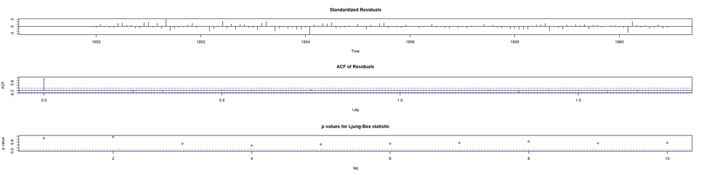

```r
at_est <- residuals(Mod2)
tsdiag(Mod2)
```

```r
# Normalidad de residuos
library(car); library(nortest)
ad.test(at_est); shapiro.test(at_est)
```

```
    Anderson-Darling normality test

data:  at_est
A = 0.68703, p-value = 0.07132
```

```
    Shapiro-Wilk normality test

data:  at_est
W = 0.98637, p-value = 0.1674
```

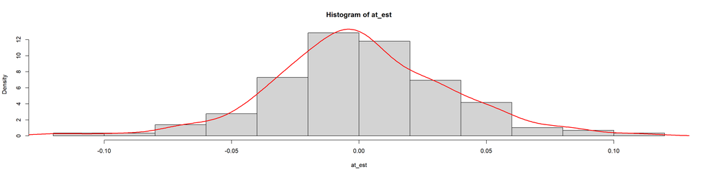

```r
hist(at_est, freq=FALSE)
lines(density(at_est), col="red", lwd=2)
```

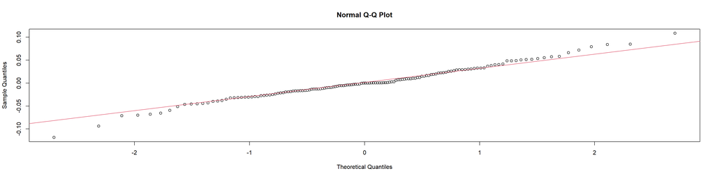

```r
qqnorm(at_est); qqline(at_est, col=2)
```

**Interpretación:**  
Residuos no muestran autocorrelación ni alejados de normalidad ⇒ modelo adecuado.

## Parte 6: CUSUM y CUSUMQ

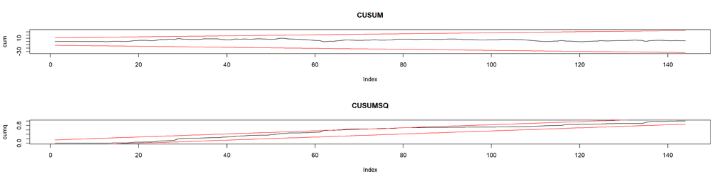

```r
cum  = cumsum(at_est)/sd(at_est)
N    = length(at_est)
cumq = cumsum(at_est^2)/sum(at_est^2)
Af   = 0.948  # 95% CUSUM
co   = 0.14013

LS   = Af*sqrt(N) + 2*Af*(1:N)/sqrt(N)
LI   = -LS
LQS  = co + (1:N)/N
LQI  = -co + (1:N)/N

par(mfrow=c(2,1))
plot(cum,  type="l", ylim=c(min(LI),max(LS)), main="CUSUM");  lines(LS, col="red"); lines(LI, col="red")
plot(cumq, type="l", main="CUSUMSQ"); lines(LQS, col="red"); lines(LQI, col="red")
```

**Conclusiones:**  
- **CUSUM:** sin cambio estructural.  
- **CUSUMQ:** posible heterocedasticidad moderada ⇒ probar ARCH.

## Parte 7: Pronóstico

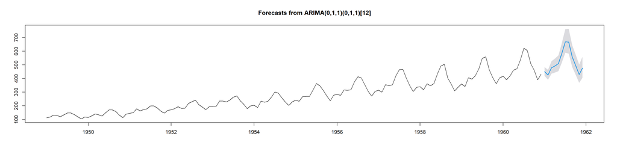

```r
par(mfrow=c(1,1))
pronosticos12 = forecast::forecast(Mod2, h=12, level=0.95)
plot(pronosticos12)
```

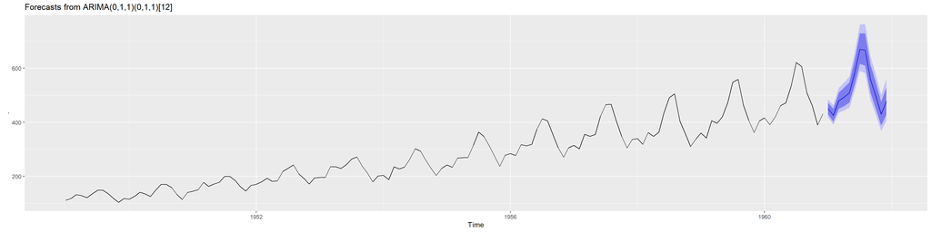

```r
# Con ggplot2
AirPassengers %>%
  forecast::Arima(order=c(0,1,1), seasonal=c(0,1,1), lambda=0, method="ML") %>%
  forecast::forecast(h=12) %>%
  autoplot()
```

**Uso práctico:**  
Las proyecciones con bandas de confianza guían decisiones de capacidad y planificación en transporte aéreo.

### Notas de modelado SARIMA

- Identificar $d,D$ con `ndiffs`, `nsdiffs`.
- ACF estacional: picos en múltiplos de 12 ⇒ componente SMA o SAR.
- PACF estacional: corte en orden $P$.
- Validar residuos (Ljung–Box, normalidad).
- Ajuste iterativo: simplificar términos insignificantes.

Este flujo implementa el método Box–Jenkins para datos estacionales.